# Assignment 2: Fire-spread model in NetLogo

Author

SADIA TAHSIN (157998114)

Published

August 19, 2026

## Part A: Build the model

```
globals [
  initial-trees
  burned-trees
]

to setup
  clear-all
  ask patches [
    if random 100 < density [ set pcolor green ]
  ]
  ask patches with [ pxcor = min-pxcor ] [
    if pcolor = green [ set pcolor red ]
  ]
  set initial-trees count patches with [ pcolor = green or pcolor = red ]
  set burned-trees 0
  reset-ticks
end

to go
  if not any? patches with [ pcolor = red ] [ stop ]
  ask patches with [ pcolor = red ] [
    ask neighbors4 with [ pcolor = green ] [
      set pcolor red
    ]
    set pcolor grey
    set burned-trees burned-trees + 1
  ]
  tick
end
```

**Task A1.**

[figure not shown]

Final state of the forest at density = 60, showing the burned (grey) and unburned (green) areas after the fire stopped spreading

**Task A2.** Percent burned at the end of the run: 80.7

## Part B: Find the critical density

**Task B1.**

| Density | Run1 | Run2 | Run3 | Run4 | Run5 | Run6 | Run7 | Run8 | Run9 | Run10 | Mean |
| --- | --- | --- | --- | --- | --- | --- | --- | --- | --- | --- | --- |
| 40 | 9.3 | 8.3 | 20.2 | 7.3 | 10.5 | 20.6 | 9.1 | 15 | 17.2 | 6.5 | 12.4 |
| 50 | 48.3 | 31.4 | 27.2 | 52.9 | 59.9 | 12.2 | 58.3 | 29.9 | 29.1 | 48.7 | 39.79 |
| 55 | 46.1 | 40.1 | 87.7 | 31.9 | 33.8 | 66.3 | 70.2 | 39.4 | 61.9 | 55.4 | 53.28 |
| 58 | 55.7 | 81.7 | 61.6 | 77.3 | 84.6 | 73.9 | 83.6 | 89.6 | 95.4 | 30.5 | 73.39 |
| 59 | 91.7 | 87.6 | 85.6 | 86.7 | 81.2 | 96.2 | 84.2 | 91 | 91.1 | 76.7 | 87.2 |
| 60 | 85.7 | 93 | 84.9 | 92 | 89 | 83.4 | 68.7 | 88.8 | 92.1 | 93.2 | 87.08 |
| 62 | 91.3 | 97.2 | 87.1 | 92.3 | 91.9 | 94.8 | 93.7 | 93 | 93.4 | 92.3 | 92.7 |
| 65 | 94.9 | 96.5 | 93.5 | 96.9 | 90.4 | 93.6 | 96.7 | 95.8 | 97.5 | 98.8 | 95.46 |
| 70 | 94.5 | 98.6 | 98.7 | 96.8 | 96.3 | 99.1 | 96.1 | 98.4 | 98.1 | 97.2 | 97.38 |
| 80 | 97.1 | 99.9 | 100 | 99.7 | 99.8 | 99.8 | 99.8 | 99.8 | 100 | 99.5 | 99.54 |

**Task B2.**

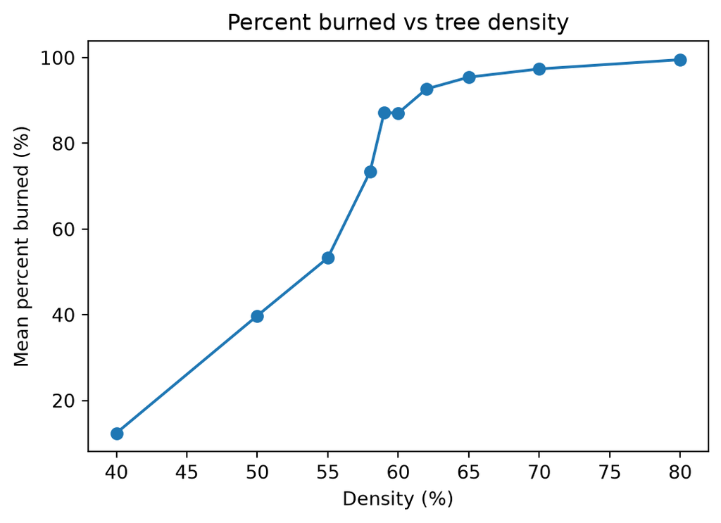

```python
import matplotlib.pyplot as plt

density = [40, 50, 55, 58, 59, 60, 62, 65, 70, 80]
mean_burned =[12.4,39.79,53.28,73.39,87.2,87.08,92.7,95.46,97.38,99.54
]  # fill in your means
fig, ax = plt.subplots(figsize=(6, 4))
ax.plot(density, mean_burned, marker="o")
ax.set_xlabel("Density (%)")
ax.set_ylabel("Mean percent burned (%)")
ax.set_title("Percent burned vs tree density")
plt.show()
```

**Task B3 (critical-density estimate).**The critical density estimate is 59. Between density 58 and 59, percent burned rose 13.81 points in just 1 unit of density — a much steeper rate than any other interval. That’s how I estimated it after seeing the graph. Compared to the theoretical value of approximately 59%, my estimate is exact.

## Part C: Summary ODD documentation

**The overall *purpose* of our model is** to predict fire burn percentage at different tree densities, in order to understand whether there is a critical density threshold at which fire behavior shifts from limited spread to widespread burning **Specifically, we are addressing the following questions:** Is there a critical tree density at which fire spread shifts sharply from limited to widespread burning? **To consider our model realistic enough for its purpose, we use the following *patterns*:** a landscape based on tree density showing a tipping point, or phase transition, where a tiny change in conditions can completely change the outcome.

**The model includes the following *entities*:** patches representing individual plots of land that may hold a tree. **The *state variables* characterising these entities are listed in Table 1.** **The *spatial* and *temporal* resolution and extent are** a world of 33×33 patches, where one patch represents a single plot of land that can either be empty or hold a tree. One tick represents one round of fire spreading to touching neighbouring patches, and a run ends when no patches remain on fire.

**The most important *processes* of the model, which are repeated every *time step*, are** burning patches set their neighbouring green (tree) patches on fire, then the previously burning patches turn to grey and are counted as burned. This continues until no patches remain on fire.

**The most important *design concepts* of the model are** emergence from local interaction in a complex system, demonstrating how macro-level phenomena emerge entirely from simple local rules between adjacent cells and tree density. The burning tree only attempts to ignite its immediate neighbours (north, south, east, west) via neighbors4. The global outcome relies heavily on the forest density parameter — minor changes near the tipping point shift the system from localized burning to total forest destruction. This randomness comes from the initial random placement of trees at setup, showing how randomness and spatial connectivity interact

**The model is initialized with** a forest grid where green patches represent trees and a red line of fire appears on the left edge. The setup clears the world, generates trees based on the chosen density, and places the initial fire ready to spread

**Table 1.** Entities and state variables of the model.

| Entity | Variable | Description | Possible values | Units |
| --- | --- | --- | --- | --- |
| Patch | `pcolor` | Whether the patch is empty, a tree, on fire, or burnt | green (tree), red (fire), grey (burnt), black (empty) | - |
| Global | `density` | Percentage of patches that start as trees | 0–100 | % |
| Global | `initial-trees` | Count of patches that started as trees | 0–1089 | count |
| Global | `burned-trees` | Count of patches that have burned | 0–1089 | count |